# Simulation experiment: new interpretation of double sampling

## Design of the experiment

This experiment is analogous to the experiment with a normal data generating mechanism. In that experiment, we assumed the use of **split-samples**: on a certain location a single field protocol (support area, number of sub-samples, depth) would be used to collect a single compound sample based on a mixture of sub-samples, and this compound sample would be split in half and one half would be analysed with a non-reference lab method and the other with a reference lab method. The use of split-samples means we eliminate field measurement error from the paired data and only lab measurement error needs to be taken into account. However, this interpretation of double-sampling is at odds with how validation data in WP4 will be collected. In this experiment we therefore simulate the data according to this revised interpretation; namely that on a certain location, two different field protocols are used to collect two different compound samples and each compound sample is analysed with a different lab method. The paired data from such a double-sampling study thus need to contain both field and lab measurement error. A TF derived on such paired data can only be used to map a unique pair of (field protocol, lab method) to another pair of (reference field protocol, reference lab method) as the field and lab components cannot be disentangled from such paired data.

We make use of the following new notation and relations:

- point values of the soil descriptor - values at point locations the size of the sampling equipment, eg. 1 cm² - have a variance in the population (area $A$) of $\sigma^2(p, A)$
- the variance of the support-area average per location in the population, $\sigma^2(a, A)$, decreases with size of the support-area: as $a$ -> $A$, $\sigma^2(a, A)$ -> 0
- the variance of the point values within a location, $\sigma^2(p, a)$, increases with size of the support-area of the location: as $a$ -> $A$, $\sigma^2(p, a)$ -> $\sigma^2(p, A)$
- Krige’s relation says the total remains constant: $\sigma^2(p, A) = \sigma^2(a, A) + \sigma^2(p, a)$. This also follows from the law of total variance.
- assuming that variance of the average per location is proportional to area: $\sigma^2(a, A) \propto a^{-\alpha}$ ($\alpha$ = scaling exponent (0 < $\alpha$ < 1 defines spatial autocorrelation), we can see that the variances of the average per location are related to each other: $\sigma^2(a_2, A) = \sigma^2(a_1, A) \left(\frac{a_1}{a_2}\right)^{\alpha}$

The above allow us to simulate paired data as follows.

We start with simulating $N$ paired values of the latent support-area averages for each field protocol [(1) & (2)] as measured with the non-reference method $X$:
$$\begin{pmatrix} X_{\mathrm{latent}}^{(1)}\\ X_{\mathrm{latent}}^{(2)} \end{pmatrix}
\sim \mathcal{N}
\left(
\begin{pmatrix} \mu_X \\ \mu_X \end{pmatrix},
\begin{pmatrix} \sigma^2(a_1, A)\ & \rho\sigma(a_1, A)\sigma(a_2, A) \\
\rho\sigma(a_1, A)\sigma(a_2, A) & \sigma^2(a_2, A) \end{pmatrix}
\right)$$
, i.e. we simulate latent values for the non-reference lab method under both field protocols. Later on we will just retain only one value from this and ignore the other. We make the latent support-area averages to be correlated to each other ($\rho$): even though the two field protocols have a different support area, the overlap between both areas on the same location makes that the latent values should be correlated but not equal.

Next we transform the latent non-reference lab method to the reference lab method under both field protocols. Same as above, later on we will just retain only one value from this and ignore the other.

$$\begin{aligned}
Y_{\mathrm{latent}}^{(1)} &= \beta_0 + \beta_1X_{\mathrm{latent}}^{(1)} \\
Y_{\mathrm{latent}}^{(2)} &= \beta_0 + \beta_1X_{\mathrm{latent}}^{(2)}
\end{aligned}$$

We can now add simulated field measurement error. The field measurement error comes from approximating support-area averages with $n$ sub-samples and follows the usual variance of the mean formula: $\frac{\sigma^2(p, a)}{n}$

$$\begin{aligned}
\begin{pmatrix} \epsilon^{(1)}\\ \epsilon^{(2)} \end{pmatrix}
&\sim \mathcal{N}
\left(
\begin{pmatrix} 0 \\ 0 \end{pmatrix},
\begin{pmatrix} \frac{\sigma^2(p, a_1)}{n_1}\ & \rho_f\frac{\sigma(p, a_1)\sigma(p, a_2)}{\sqrt{n_1n_2}} \\
\rho_f\frac{\sigma(p, a_1)\sigma(p, a_2)}{\sqrt{n_1n_2}} & \frac{\sigma^2(p, a_2)}{n_2} \end{pmatrix}
\right) \\
X_{\mathrm{obs,field}}^{(1)} &= X_{\mathrm{latent}}^{(1)} + \epsilon^{(1)} \\
Y_{\mathrm{obs,field}}^{(1)} &= Y_{\mathrm{latent}}^{(1)} + \epsilon^{(1)} \\
X_{\mathrm{obs,field}}^{(2)} &= X_{\mathrm{latent}}^{(2)} + \epsilon^{(2)} \\
Y_{\mathrm{obs,field}}^{(2)} &= Y_{\mathrm{latent}}^{(2)} + \epsilon^{(2)}
\end{aligned}$$
(in all generality, we allow measurement error between both field protocols to be correlated with magnitude $\rho_f$ but we expect this value to be low; correlation could occur when point locations would happen to be very close between two field protocols, for example when the national protocol selects points right next to the LUCAS points plus some additional ones)

Next we add lab measurement error to the observations. We will assume that lab measurement errors are smaller than field sampling measurement error by a factor $\tau_x$: $\sigma_X = \tau_{x} \frac{\sigma(p, a_2)}{\sqrt{n_2}}$ and we assume that lab measurement errors of both methods are of the same magnitude: $\sigma_Y = \tau_{xy} \sigma_X$ with $\tau_{xy} = 1$ (but this could be relaxed). As we are not working with split-samples, the lab measurement error is expected to be uncorrelated now: $\rho_l = 0$ (with split samples, correlated measurement error could occur from shared pre-processing of the compound sample).

$$\begin{aligned}
\begin{pmatrix} \epsilon_X\\ \epsilon_Y \end{pmatrix}
&\sim \mathcal{N}
\left(
\begin{pmatrix} 0 \\ 0 \end{pmatrix},
\begin{pmatrix} \sigma^2_X & 0 \\
0 & \sigma^2_Y \end{pmatrix}
\right) \\
X_{\mathrm{obs,lab}}^{(1)} &= X_{\mathrm{obs,field}}^{(1)} + \epsilon_X \\
Y_{\mathrm{obs,lab}}^{(1)} &= Y_{\mathrm{obs,field}}^{(1)} + \epsilon_Y \\
X_{\mathrm{obs,lab}}^{(2)} &= X_{\mathrm{obs,field}}^{(2)} + \epsilon_X \\
Y_{\mathrm{obs,lab}}^{(2)} &= Y_{\mathrm{obs,field}}^{(2)} + \epsilon_Y
\end{aligned}$$

The following values of each parameter are examined. One parameter is varied at a time while the others are kept at the default value (first value indicated). This gives a total of 33 scenario’s: each scenario is replicated 250 times. The values are chosen to approximate realistic values for pH.

Table: Parameter values for the scenario’s. The default value is the first in each list.

| Parameter | Values |
| --- | --- |
| $N$ | 200, 100, 500 |
| $\mu$ | 7 |
| $\sigma^2(p,A)$ | 2 |
| $\sigma^2(a_1,A)$ | 1.9 |
| $a_1 / a2$ | 1, 0.5, 0.2, 0.1 |
| $n_1$ | 4, 8, 16 |
| $n_1 / n_2$ | 1, 0.5, 0.25 |
| $\alpha$ | 0.1, 0.05, 0.2 |
| $\rho_{\text{latent}}$ | 0.9, 0.99 |
| $\rho_{\text{me, field}}$ | 0, 0.1, 0.3 |
| $\rho_{\text{me, lab}}$ | 0 |
| $\beta_0$ | 0, 0.1, 0.2 |
| $\beta_1$ | 1, 0.7, 0.9, 1.1, 1.3 |
| $\tau_x$ | 0.05, 0.01, 0.1, 0.2 |
| $\tau_{xy}$ | 1 |

## Description of the models

Simple linear regression (frequentist).

## Worked example

The following provide a worked example of 1 simulation replicate.

- Let’s say we double-sample $N$ = 200 locations.
- Protocol 1 = LUCAS ($a_1$ = 4$\pi$ m², $n_1$ = 5 sub-samples).
- Protocol 2 = CMON, Flanders ($a_2$ = 100 m², $n_2$ = 16 sub-samples)
- mean in the population: $\mu$ = 7 (eg soil pH)
- variance of point-values in the population: $\sigma^2(p, A)$ = 2
- for LUCAS the variance of latent support-area averages: $\sigma^2(a_1, A)$ = 1.9
- spatial autocorrelation: $\alpha$ = 0.1 (smooth)

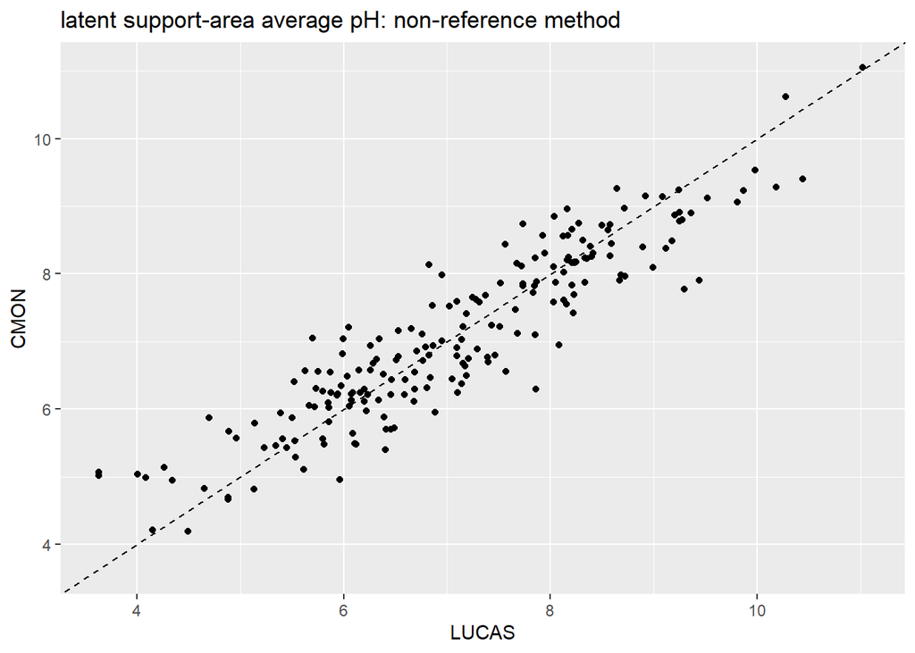

```r
# field protocols
a1 <- 4 * pi
a2 <- 100
n1 <- 5
n2 <- 16

# assumptions
N                     <- 200
mu_x                  <- 7
sigma2_pA             <- 2
sigma2_support1       <- 1.9
spatautocor           <- 0.1
corr_latent           <- .90
beta0                 <- 0.05
beta1                 <- 1.1
corr_mefield          <- 0
corr_melab            <- 0
ratio_labmex_fieldmex <- .05
ratio_labmey_labmex   <- 1

# variance of support-average values (protocol 2)
R_a             <- (a1 / a2)^spatautocor
sigma2_support2 <- sigma2_support1 * R_a

# variance of within-support point values (Krige's relation)
sigma2_wpoint1 <- sigma2_pA - sigma2_support1
sigma2_wpoint2 <- sigma2_pA - sigma2_support2

# sampling variance from taking n sub-samples within the support:
sigma2_sampling1 <- sigma2_wpoint1 / n1
sigma2_sampling2 <- sigma2_wpoint2 / n2

# simulate latent support-area averages under both field protocols
# with the non-reference method
var_latent <- matrix(
    c(sigma2_support1,
      rep(sqrt(sigma2_support1 * sigma2_support2) * corr_latent, 2),
      sigma2_support2),
    byrow = TRUE, nrow = 2
  )
latent_x <- MASS::mvrnorm(N, rep(mu_x, 2), var_latent) |>
  as.data.frame()

ggplot(latent_x, aes(V1, V2)) +
  geom_point() +
  geom_abline(intercept = 0, slope = 1, lty = 2) +
  labs(x = "LUCAS", y = "CMON",
       title = "latent support-area average pH: non-reference method") +
  xlim(min(latent_x), max(latent_x)) + ylim(min(latent_x), max(latent_x))
```

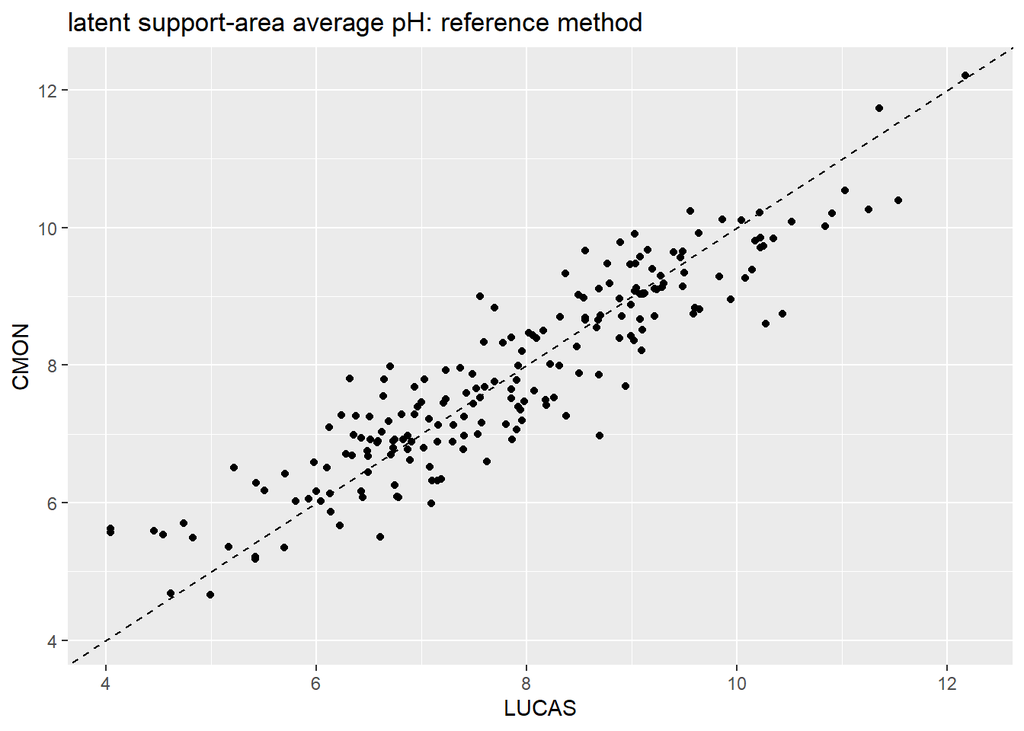

```r
# TF from the non-reference method to the reference method with both protocols
latent_y <- beta0 + beta1 * latent_x

ggplot(latent_y, aes(V1, V2)) +
  geom_point() +
  geom_abline(intercept = 0, slope = 1, lty = 2) +
  labs(x = "LUCAS", y = "CMON",
       title = "latent support-area average pH: reference method") +
  xlim(min(latent_y), max(latent_y)) + ylim(min(latent_y), max(latent_y))
```

```r
# mixing method and protocol in outcome and predictor makes we cannot recover
# the regression coefficients
# and that's before adding measurement error
lm(latent_y$V1 ~ latent_x$V2)
```

```
Call:
lm(formula = latent_y$V1 ~ latent_x$V2)

Coefficients:
(Intercept)  latent_x$V2
   -0.06362      1.11769
```

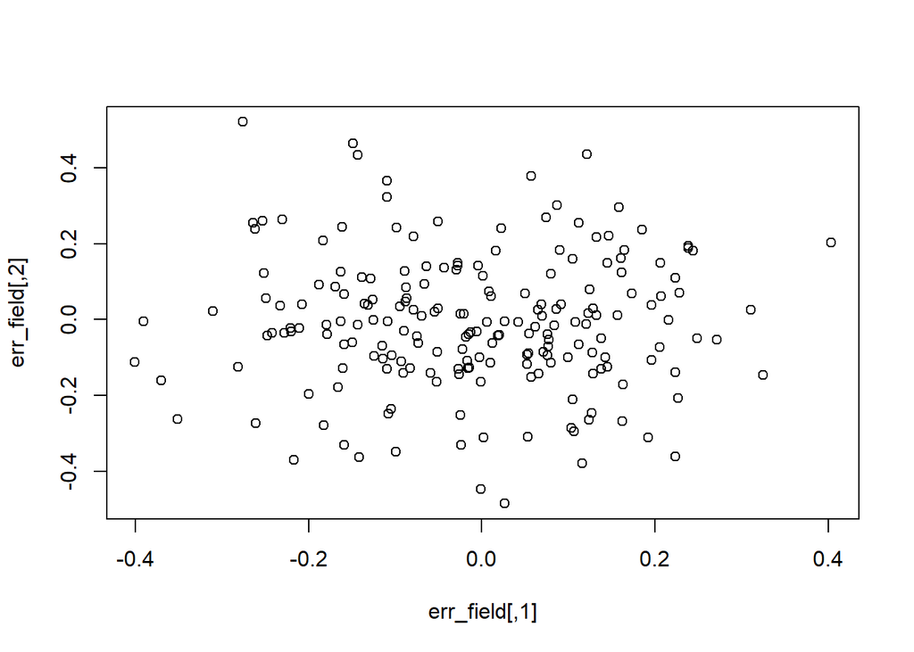

```r
# field sub-sampling error (approximating support mean with n sub-samples)
varme_field <- matrix(
  c(sigma2_sampling1,
    rep(sqrt(sigma2_sampling1 * sigma2_sampling2) * corr_mefield, 2),
    sigma2_sampling2),
  byrow = TRUE, nrow = 2
)
err_field <- MASS::mvrnorm(N, rep(0, 2), varme_field)
plot(err_field)
```

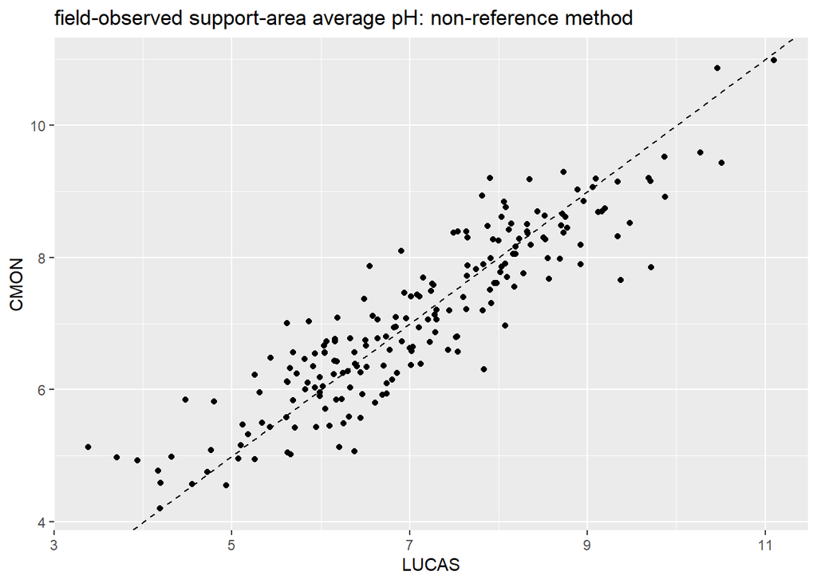

```r
# obs_field_% is what we would observe if there was no lab measurement error
obs_field_x <- latent_x + err_field
obs_field_y <- latent_y + err_field

ggplot(obs_field_x, aes(V1, V2)) +
  geom_point() +
  geom_abline(intercept = 0, slope = 1, lty = 2) +
  labs(x = "LUCAS", y = "CMON",
       title = "field-observed support-area average pH: non-reference method")
```

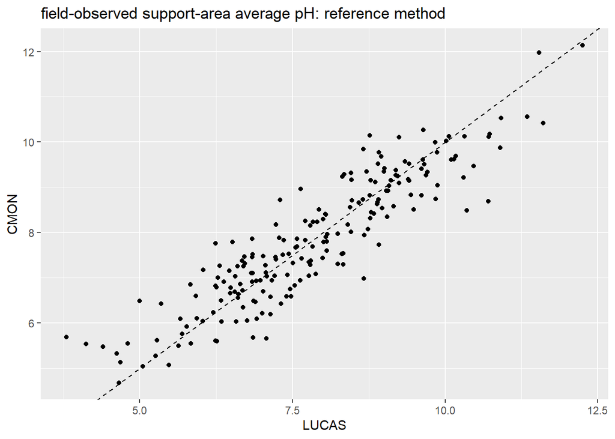

```r
ggplot(obs_field_y, aes(V1, V2)) +
  geom_point() +
  geom_abline(intercept = 0, slope = 1, lty = 2) +
  labs(x = "LUCAS", y = "CMON",
       title = "field-observed support-area average pH: reference method")
```

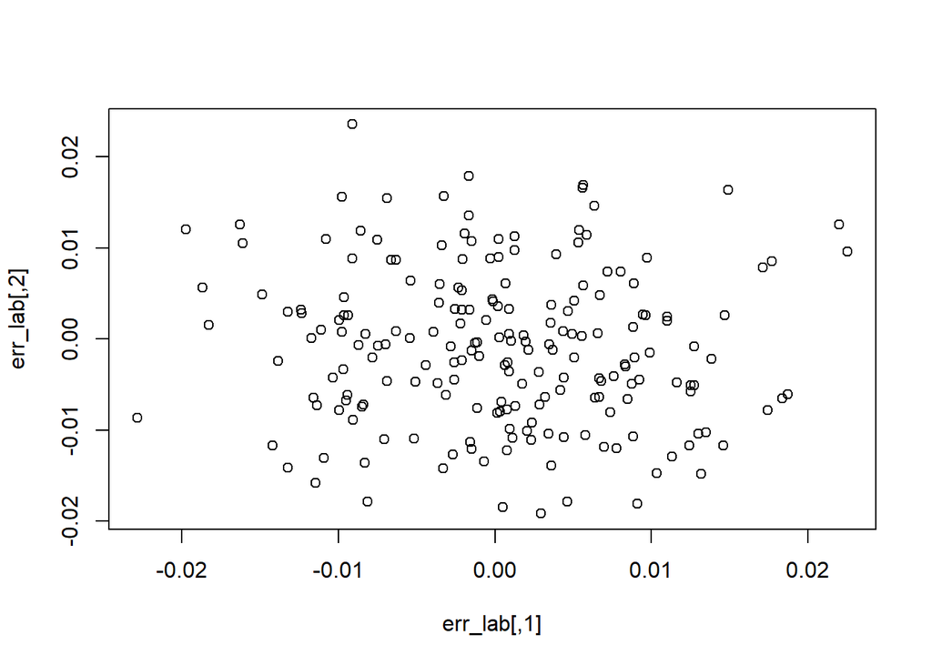

```r
sd_lab_mex <- ratio_labmex_fieldmex * sqrt(sigma2_sampling2)
sd_lab_mey <- ratio_labmey_labmex * sd_lab_mex
varme_lab  <- matrix(
  c(sd_lab_mex^2, rep(sd_lab_mex * sd_lab_mey * corr_melab, 2), sd_lab_mey^2),
  byrow = TRUE, nrow = 2
)
err_lab   <- MASS::mvrnorm(N, rep(0, 2), varme_lab)
obs_lab_x <- obs_field_x + err_lab
obs_lab_y <- obs_field_y + err_lab
plot(err_lab)
```

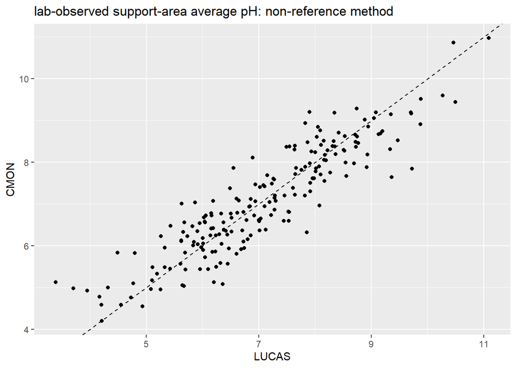

```r
ggplot(obs_lab_x, aes(V1, V2)) +
  geom_point() +
  geom_abline(intercept = 0, slope = 1, lty = 2) +
  labs(x = "LUCAS", y = "CMON",
       title = "lab-observed support-area average pH: non-reference method")
```

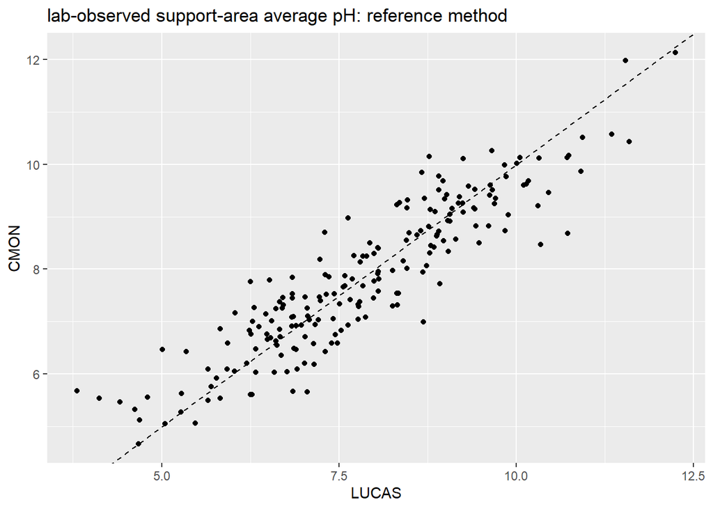

```r
ggplot(obs_lab_y, aes(V1, V2)) +
  geom_point() +
  geom_abline(intercept = 0, slope = 1, lty = 2) +
  labs(x = "LUCAS", y = "CMON",
       title = "lab-observed support-area average pH: reference method")
```

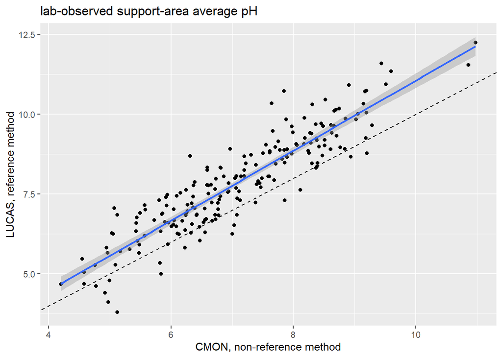

```r
# in the end, we only observe 1 method from each protocol
observed <- data.frame(
  CMON_nonref = obs_lab_x$V2,
  LUCAS_ref   = obs_lab_y$V1
)

ggplot(observed, aes(CMON_nonref, LUCAS_ref)) +
  geom_point() +
  geom_smooth(method = "lm") +
  geom_abline(intercept = 0, slope = 1, lty = 2) +
  labs(x = "CMON, non-reference method", y = "LUCAS, reference method",
       title = "lab-observed support-area average pH")
```

```r
# fit a TF on the observed data
mod <- lm(
  LUCAS_ref ~ 1 + CMON_nonref,
  data = observed
)
summary(mod)
```

```
Call:
lm(formula = LUCAS_ref ~ 1 + CMON_nonref, data = observed)

Residuals:
     Min       1Q   Median       3Q      Max
-1.89886 -0.41781 -0.01993  0.44005  2.03122

Coefficients:
            Estimate Std. Error t value Pr(>|t|)
(Intercept)  0.08399    0.26157   0.321    0.748
CMON_nonref  1.09692    0.03637  30.159   <2e-16 ***
---
Signif. codes:  0 '***' 0.001 '**' 0.01 '*' 0.05 '.' 0.1 ' ' 1

Residual standard error: 0.6667 on 198 degrees of freedom
Multiple R-squared:  0.8212,    Adjusted R-squared:  0.8203
F-statistic: 909.6 on 1 and 198 DF,  p-value: < 2.2e-16
```

```r
confint(mod)
```

```
                 2.5 %   97.5 %
(Intercept) -0.4318346 0.599823
CMON_nonref  1.0251929 1.168641
```

```r
# make a large validation dataset and apply the fitted TF on it
N_val        <- 1e4
latent_x_val <- MASS::mvrnorm(N_val, rep(mu_x, 2), var_latent) |>
  as.data.frame()
latent_y_val    <- beta0 + beta1 * latent_x_val
err_field_val   <- MASS::mvrnorm(N_val, rep(0, 2), varme_field)
obs_field_x_val <- latent_x_val + err_field_val
obs_field_y_val <- latent_y_val + err_field_val
err_lab_val     <- MASS::mvrnorm(N_val, rep(0, 2), varme_lab)
obs_lab_x_val   <- obs_field_x_val + err_lab_val
obs_lab_y_val   <- obs_field_y_val + err_lab_val

observed_val <- data.frame(
  CMON_nonref = obs_lab_x_val$V2,
  LUCAS_ref   = obs_lab_y_val$V1
)

predicted_val <- predict(
  mod, newdata = observed_val, interval = "prediction"
) |> as.data.frame()

# nominal coverage?
mean( between(observed_val$LUCAS_ref, predicted_val$lwr, predicted_val$upr) )
```

```
[1] 0.938
```

## Evaluation of the models

See report normal DGM: R², PICP, MAE, MPE, RMSE, SDPE

## Results

The following figures present the results of the simulations for each parameter that was varied, keeping the other parameters fixed.

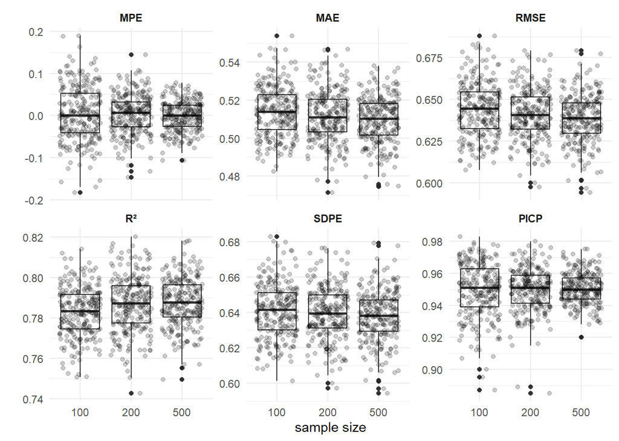

Figure 1: Sample size of the calibration (training) dataset

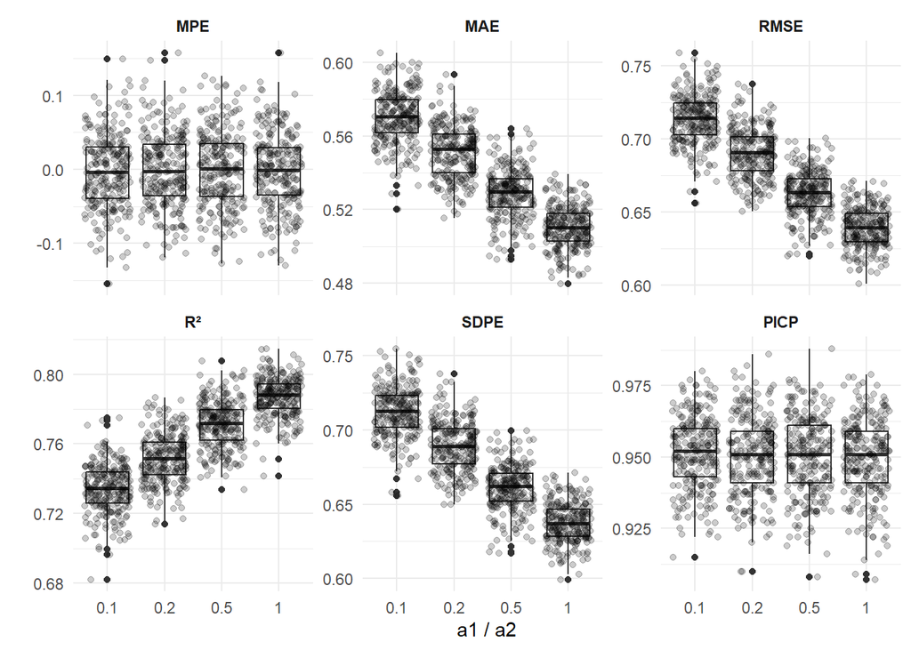

Figure 2: Ratio between the support area’s of both field protocols

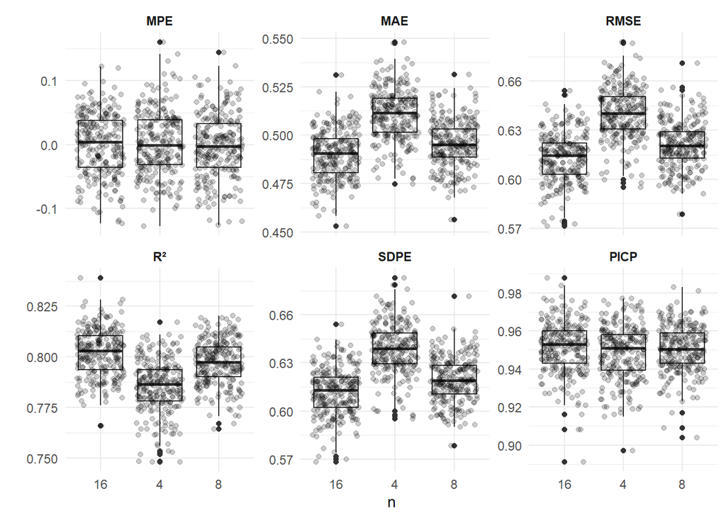

Figure 3: Number of subsamples

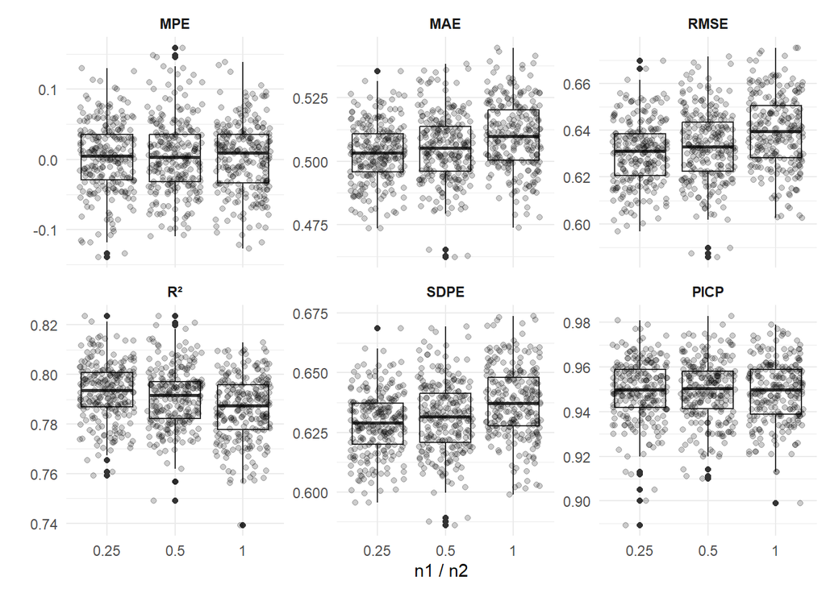

Figure 4: Ratio between subsamples in both protocols

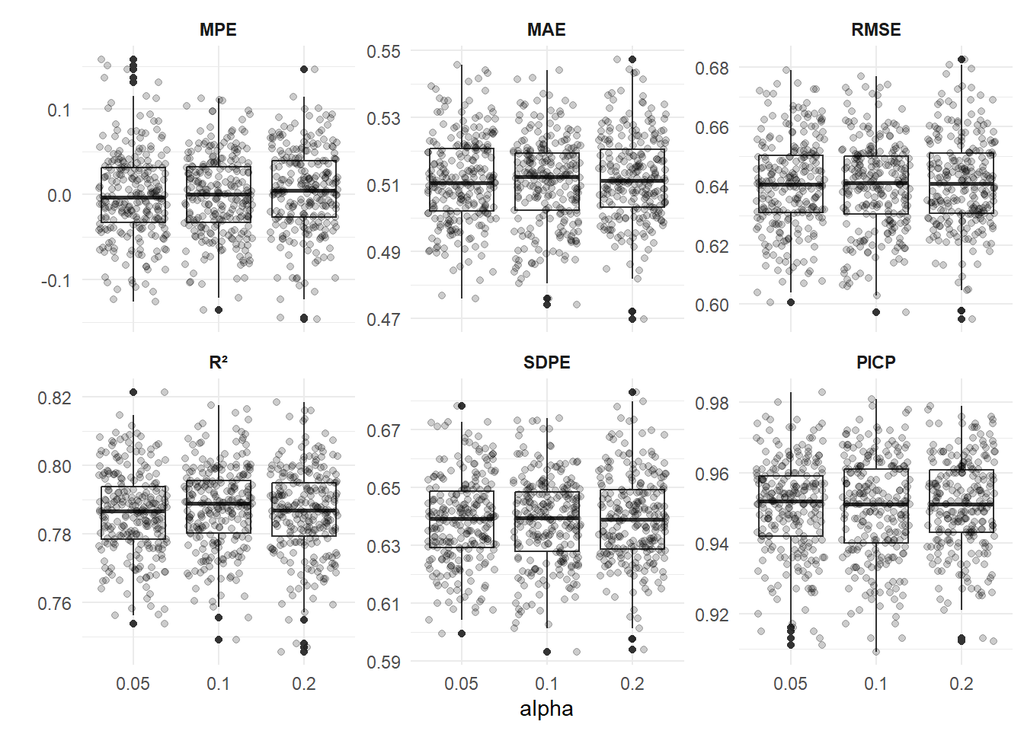

Figure 5: Spatial autocorrelation (zero = absolute smoothness)

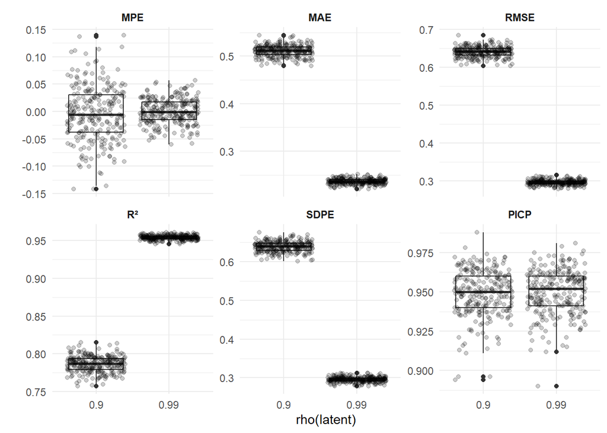

Figure 6: Correlation between latent support-area averages

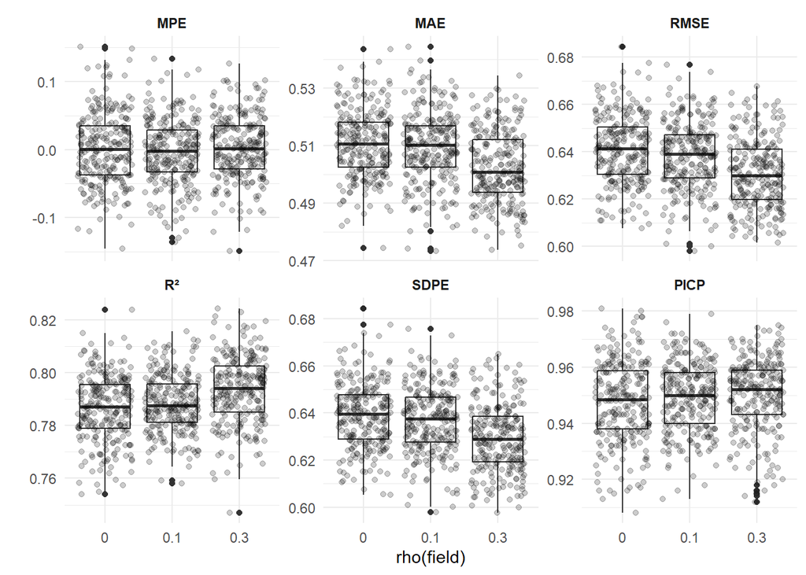

Figure 7: Correlation between field measurement error

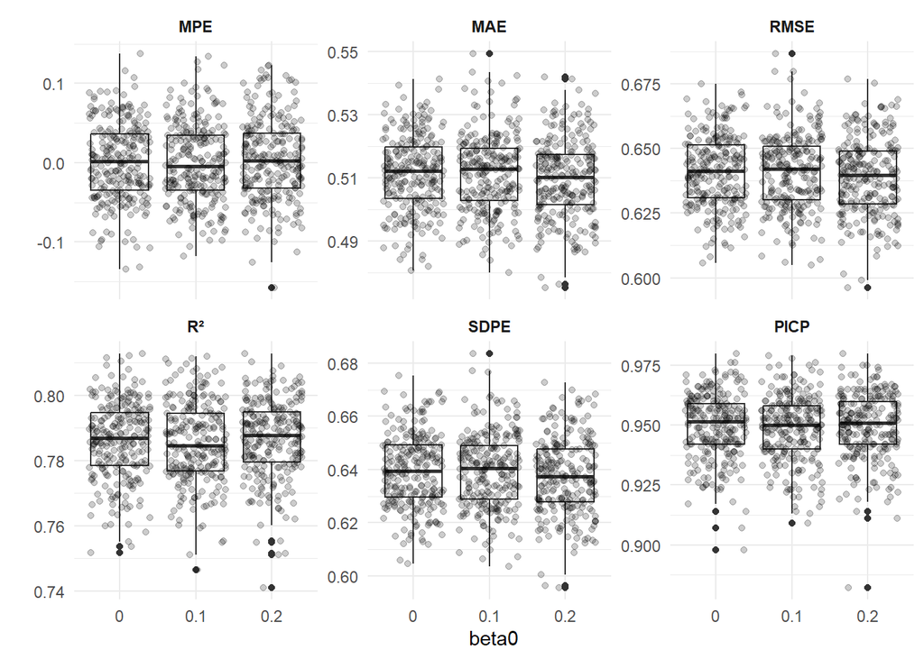

Figure 8: Intercept of the TF between the latent support-area averages

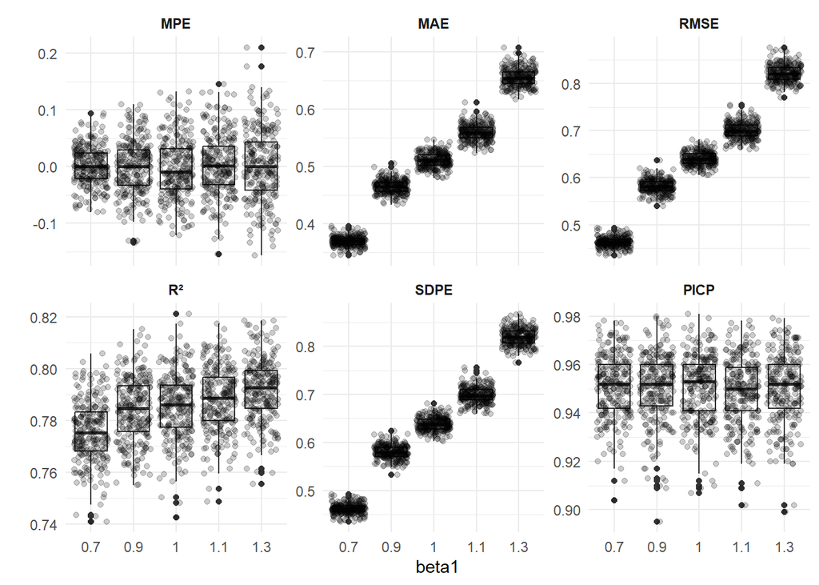

Figure 9: Slope of the TF between the latent support-area averages

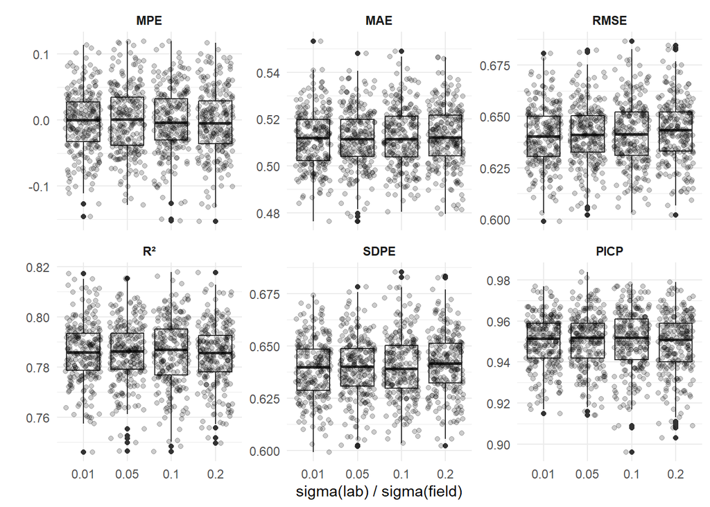

Figure 10: Ratio between measurement error: lab / field

## Conclusions

- the derived TF’s in this way are valid only for a mapping of 1 pair of (field protocol, lab method) to another pair and cannot be used in any other way; this probably means that only national TF’s can be developed as all countries have slight variations in field protocols (no European-wide TF)
- coverage (PICP) is preserved across scenarios
- EIV-models would need even more parameters as before (see other experiments), making it even more un-identifiable probably